# Analysis of a TCGA RNA-seq data set on Kidney Clear Cell Carcinoma

J. Sanchez, P. Badia and G. Palou

Master Programme on Bioinformatics for Health Sciences, Universitat Pompeu Fabra, Barcelona, Catalonia

javier.sanchez14@estudiant.upf.edu  
pau.badia01@estudiant.upf.edu  
guillermo.palou@upf.edu

May 5, 2019

# 1 Introduction

Kidney Clear Cell Carcinoma or clear cell renal cell carcinoma (ccRCC), is a chemotherapy-resistant disease that can be distinguished of other cancer because affected cells show a clear cytoplasm, are surrounded by a distinct cell membrane and contain round and uniform nuclei. Inherited predisposition to ccRCC has been shown to arise from genes involved in regulating cellular metabolism, making ccRCC a model for the role of an oncologic-metabolic shift. The Cancer Genome Atlas (TCGA) has comprehensively profiled this type of cancer in a patient cohort. Here we analyze the expression profiles of those patients, accessible in the form of a raw RNA-seq counts produced by TCGA (2013) using a pipeline based on the R/Bioconductor software package `Rsubread`.

This document is written in [R markdown](https://rmarkdown.rstudio.com) and should be processed using R and you need to install the packages *knitr* and *markdown*. Moreover, it using the official style for Bioconductor vignettes facilitated by the Bioconductor package *BiocStyle*. Please consult that package documentation, and particularly the [vignette](http://bioconductor.org/packages/release/bioc/vignettes/BiocStyle/inst/doc/AuthoringRmdVignettes.html) on “Authoring R Markdown vignettes”, for full details on how to elaborate this kind of documents.

The specific instructions to generate the final HTML report are written in a Makefile. To run it you just need to type

`$ make`

on the unix shell. The `makefile` contains instructions to separately process the different files that integrate this report, and so only the file that has been modified will be rebuilt. If you wish to remove or add files to be processed, you should modify the `makefile`.

The directory `results` will contain resulting files produced during the analysis, however, figures are going to end by default directories associated with the source filenames from where they were created.

# 2 Quality analysis

Before starting, we need to import all the libraries that are going to be used in this analysis.

```r
library(knitr)
library(SummarizedExperiment)
library(edgeR)
library(geneplotter)
library(sva)
library(ggplot2)
```

## 2.1 Data import

First, we import the dataset and store it in a `SummarizedExperiment` object, named `se`. This kind of object has genes on its rows and samples on its columns, 20,115 genes and 614 samples in our case. Both of these entities have their own associated metadata, i.e., gene symbol, lenght and GC content for genes. For samples, there are more than 500 more fields, for instance type, gender and race.

```r
se <- readRDS(file.path("input","seKIRC.rds"))
se
```

```
## class: RangedSummarizedExperiment
## dim: 20115 614
## metadata(5): experimentData annotation cancerTypeCode
##   cancerTypeDescription objectCreationDate
## assays(1): counts
## rownames(20115): 1 2 ... 102724473 103091865
## rowData names(3): symbol txlen txgc
## colnames(614): TCGA.3Z.A93Z.01A.11R.A37O.07
##   TCGA.6D.AA2E.01A.11R.A37O.07 ... TCGA.CZ.5988.11A.01R.1672.07
##   TCGA.CZ.5989.11A.01R.1672.07
## colData names(549): type bcr_patient_uuid ...
##   lymph_nodes_aortic_pos_by_ihc lymph_nodes_aortic_pos_total
```

Next, we explore the dimensions of the column data of the `se` object, containing the samples data and we observe that it has 614 rows (samples) and 549 columns (metadata fields). To see the possible values that each clinical variable can have we use `mcols` function.

```r
dim(colData(se))
```

```
## [1] 614 549
```

```r
colData(se)[1:5, 1:5]
```

```
## DataFrame with 5 rows and 5 columns
##                                  type                     bcr_patient_uuid
##                              <factor>                             <factor>
## TCGA.3Z.A93Z.01A.11R.A37O.07    tumor 2B1DEA0A-6D55-4FDD-9C1C-0D9FBE03BD78
## TCGA.6D.AA2E.01A.11R.A37O.07    tumor D3B47E53-6F40-4FC8-B5A4-CBE548A770A9
## TCGA.A3.3306.01A.01R.0864.07    tumor 9fb55e0b-43d8-40a3-8ef2-d198e6290551
## TCGA.A3.3307.01A.01R.0864.07    tumor 7ac1d6c6-9ade-49af-8794-10b5b96b2b05
## TCGA.A3.3308.01A.02R.1325.07    tumor 3cbca837-f5a7-4a87-8f02-c59eac232d5a
##                              bcr_patient_barcode form_completion_date
##                                         <factor>             <factor>
## TCGA.3Z.A93Z.01A.11R.A37O.07        TCGA-3Z-A93Z           2014-11-11
## TCGA.6D.AA2E.01A.11R.A37O.07        TCGA-6D-AA2E            2014-3-17
## TCGA.A3.3306.01A.01R.0864.07        TCGA-A3-3306            2010-8-23
## TCGA.A3.3307.01A.01R.0864.07        TCGA-A3-3307            2010-4-13
## TCGA.A3.3308.01A.02R.1325.07        TCGA-A3-3308            2010-4-12
##                              prospective_collection
##                                            <factor>
## TCGA.3Z.A93Z.01A.11R.A37O.07                    YES
## TCGA.6D.AA2E.01A.11R.A37O.07                    YES
## TCGA.A3.3306.01A.01R.0864.07                     NO
## TCGA.A3.3307.01A.01R.0864.07                     NO
## TCGA.A3.3308.01A.02R.1325.07                     NO
```

```r
mcols(colData(se), use.names=TRUE)
```

```
## DataFrame with 549 rows and 2 columns
##                                                          labelDescription
##                                                               <character>
## type                                           sample type (tumor/normal)
## bcr_patient_uuid                                         bcr patient uuid
## bcr_patient_barcode                                   bcr patient barcode
## form_completion_date                                 form completion date
## prospective_collection            tissue prospective collection indicator
## ...                                                                   ...
## lymph_nodes_pelvic_pos_total                               total pelv lnp
## lymph_nodes_aortic_examined_count                           total aor lnr
## lymph_nodes_aortic_pos_by_he                          aln pos light micro
## lymph_nodes_aortic_pos_by_ihc                                 aln pos ihc
## lymph_nodes_aortic_pos_total                                total aor-lnp
##                                         CDEID
##                                   <character>
## type                                       NA
## bcr_patient_uuid                           NA
## bcr_patient_barcode                   2673794
## form_completion_date                       NA
## prospective_collection                3088492
## ...                                       ...
## lymph_nodes_pelvic_pos_total          3151828
## lymph_nodes_aortic_examined_count     3104460
## lymph_nodes_aortic_pos_by_he          3151832
## lymph_nodes_aortic_pos_by_ihc         3151831
## lymph_nodes_aortic_pos_total          3151827
```

These metadata consists of two columns of information about the clinical variables. One called `labelDescription` contains a succint description of the variable, often not more self-explanatory than the variable name itself, and the other called ‘CDEID’ corresponds to the so-called `Common Data Element (CDE)` identifier. This identifier can be use in https://cdebrowser.nci.nih.gov to search for further information about the associated clinical variable using the `Advanced search` form and the `Public ID` attribute search.

We do the same with the gene data and observe the metadata mentioned before.

```
## [1] 20115     3
```

```
## DataFrame with 20115 rows and 3 columns
##                symbol     txlen              txgc
##           <character> <integer>         <numeric>
## 1                A1BG      3322 0.564419024683925
## 2                 A2M      4844 0.488232865400495
## 9                NAT1      2280 0.394298245614035
## 10               NAT2      1322 0.389561270801815
## 12           SERPINA3      3067 0.524942940984676
## ...               ...       ...               ...
## 100996331       POTEB      1706 0.430832356389215
## 101340251    SNORD124       104 0.490384615384615
## 101340252   SNORD121B        81 0.407407407407407
## 102724473      GAGE10       538 0.505576208178439
## 103091865   BRWD1-IT2      1028 0.592412451361868
```

To perform quality assessment and normalization we use the edgeR R/Bioconductor package and create a `DGEList` objec, which we are going to save in the file `dge.rds`.

```r
dge <- DGEList(counts=assays(se)$counts, genes=mcols(se))
saveRDS(dge, file.path("results", "dge.rds"))
```

## 2.2 Within-sample normalization

Now we calculate $\log_2$ CPM values of expression and put them as an additional assay element to ease their manipulation.

```r
assays(se)$logCPM <- cpm(dge, log=TRUE, prior.count=0.5)
assays(se)$logCPM[1:5, 1:5]
```

```
##    TCGA.3Z.A93Z.01A.11R.A37O.07 TCGA.6D.AA2E.01A.11R.A37O.07
## 1                      3.681094                     1.308506
## 2                     11.070451                     9.467119
## 9                     -6.544714                    -6.544714
## 10                    -6.544714                    -6.544714
## 12                     5.196098                     5.386859
##    TCGA.A3.3306.01A.01R.0864.07 TCGA.A3.3307.01A.01R.0864.07
## 1                    -0.2268151                     0.203261
## 2                     9.8676287                    11.166993
## 9                    -6.5447145                    -6.544714
## 10                   -6.5447145                    -6.544714
## 12                    4.6330031                     5.479129
##    TCGA.A3.3308.01A.02R.1325.07
## 1                     0.2380578
## 2                    11.2922910
## 9                    -6.5447145
## 10                   -6.5447145
## 12                    5.8638782
```

## 2.3 Distribution and filtering of sequencing depth (first filtering)

We then examine the sequencing depth in terms of total number of sequence read counts mapped to the genome per sample.

```r
ord <- order(dge$sample$lib.size)
summary(dge$sample$lib.size/1e+06)
```

```
##    Min. 1st Qu.  Median    Mean 3rd Qu.    Max.
##   3.049  38.075  46.715  46.679  54.647 115.546
```

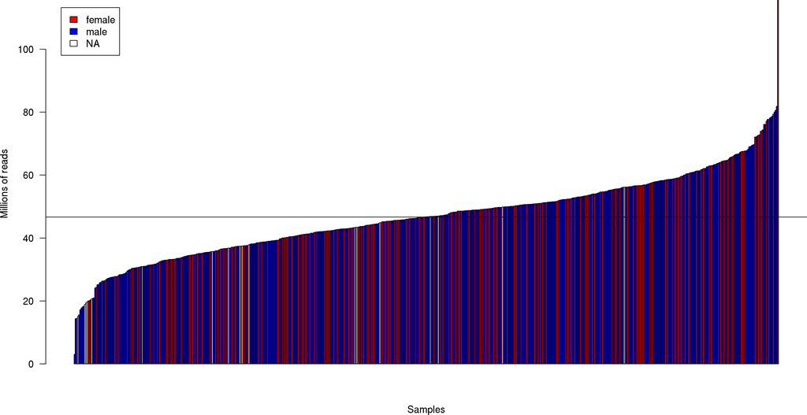

Figure 1: Library sizes in increasing order

```r
barplot(dge$sample$lib.size[ord]/1e+06, las = 1, ylab = "Millions of reads", xlab = "Samples", col = c("red", "blue")[se$gender[ord]], space=c(0,0))
legend("topleft", c("female", "male", "NA"), fill = c("red", "blue", "white"), inset = 0.02)
abline(h=(sum(colSums(assays(se)$counts))/1e6)/ncol(se))
```

Figure 1 shows the sequencing depth per sample, also known as library size, in increasing order. There is a good distribution of male and female samples with different sequencing depth. However, there is a huge difference between some samples, taking into account that the average is around 45 million reads. We apply a threshold of 21M to discard low sequencing depth samples. We use this specific value, because we can observe at the plot that there is a change in the distribution peaks (a jump from 20.9M to 24M). After the filtering, the number of samples is reduced from 614 to 596.

```r
cpm_cutoff <- 21
mask <- colSums(assays(se)$counts)/1e6 > cpm_cutoff
se.filt <- se[, mask]
dge.filt <- dge[, mask]
dim(se.filt)
```

```
## [1] 20115   596
```

We store un-normalized versions of the data filtered by sample depth (cutoff of 21 CPM).

```r
saveRDS(se.filt, file.path("results", "se.filt.unnorm.rds"))
saveRDS(dge.filt, file.path("results", "dge.filt.unnorm.rds"))
```

## 2.4 Distribution of expression levels among samples

We look at the distribution of expression values per sample in terms of logarithmic CPM units using geneplotter R/Bioconductor package.

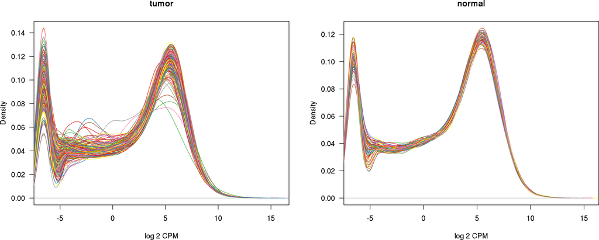

Figure 2: Non-parametric density distribution of expression profiles per sample

```r
assays(se.filt)$logCPM <- cpm(dge.filt, log=TRUE, prior.count=0.5)
par(mfrow=c(1, 2))
multidensity(as.list(as.data.frame(assays(se.filt[, se.filt$type == "tumor"])$logCPM)),
             xlab="log 2 CPM", legend=NULL, main="tumor", las=1)
multidensity(as.list(as.data.frame(assays(se.filt[, se.filt$type == "normal"])$logCPM)),
             xlab="log 2 CPM", legend=NULL, main="normal", las=1)
```

Figure 2 shows that the normal samples have a good CPM distribution, but some of the tumor samples seem to have a distinct RNA composition. Let’s see if this can be fixed later on by filtering.

## 2.5 Distribution and filtering of expression levels among genes (second filtering)

Now we calculate the average expression per gene through all the samples, and plot the distribution of expression levels across genes (Figure 3. It allows us to identify lowly expressed genes.

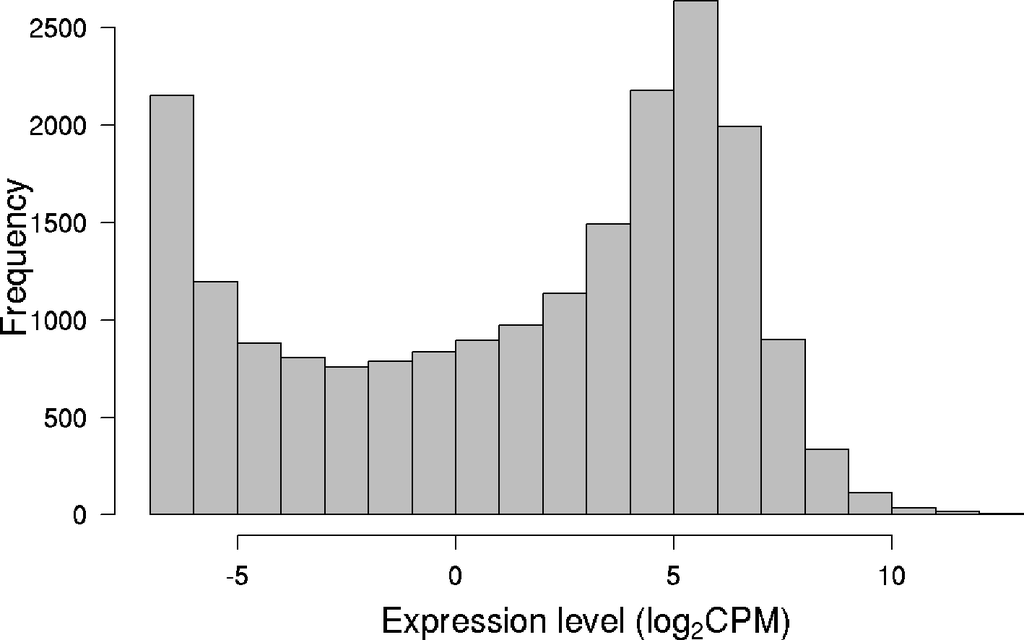

Figure 3: Distribution of average expression level per gene

```r
avgexp <- rowMeans(assays(se.filt)$logCPM)
par(mar = c(4, 5, 1, 1))
h <- hist(avgexp, xlab = expression("Expression level (" * log[2] * "CPM)"), main = "",
    las = 1, col = "grey", cex.axis = 1.2, cex.lab = 1.5)
```

RNA-seq expression profiles from lowly-expressed genes can lead to artifacts in downstream differential expression analyses. For this reason, we remove them following this criteria:

- Filter out genes with fewer than a given number of samples meeting a minimu expression (logCPM) cut-off.

In our case, the minimum CPM is 0.6 in at least 72 samples, which is the sample size of the control group.

```r
# CPM cutoff
cpm_cutoff <- round(15/min(dge.filt$samples$lib.size/1e+06), digits = 1)
cpm_cutoff
```

```
## [1] 0.6
```

```r
nsamplescutoff <- min(table(se.filt$type))
nsamplescutoff
```

```
## [1] 72
```

```r
mask <- rowSums(cpm(dge.filt) > cpm_cutoff) >= nsamplescutoff
se.filt2 <- se.filt[mask, ]
dge.filt2 <- dge.filt[mask, ]
dim(se.filt2)
```

```
## [1] 14777   596
```

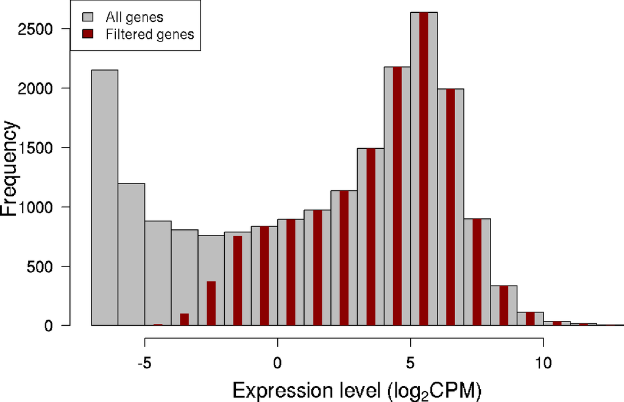

Figure 4: Distribution of average expression level per gene, showing the filtered genes in red

```r
# Plot
par(mar = c(4, 5, 1, 1))
h <- hist(avgexp, xlab = expression("Expression level (" * log[2] * "CPM)"), main = "",
    las = 1, col = "grey", cex.axis = 1.2, cex.lab = 1.5)
x <- cut(rowMeans(assays(se.filt2)$logCPM), breaks = h$breaks)
lines(h$mids, table(x), type = "h", lwd = 10, lend = 1, col = "darkred")
legend("topleft", c("All genes", "Filtered genes"), fill = c("grey", "darkred"))
```

After the filtering, we remove most of the lowly-expressed genes, but as we can observe in Figure 4 still some of them are not removed (negative log2 CPM). These are lowly-expressed genes that only are expressed in normal samples (thus follows the criteria). Because they are not expressed in tumor samples, the average CPM is negative. However, genes that are expressed, although not very significantly, in normal samples but not in tumor onees might be of interest.

We store the un-normalized versions of the data filtered by gene expression (cutoff of 0.6 CPM expressed in at least 72 samples).

```r
saveRDS(se.filt2, file.path("results", "se.filt2.unnorm.rds"))
saveRDS(dge.filt2, file.path("results", "dge.filt2.unnorm.rds"))
```

## 2.6 Between-sample normalization

We calculate now the normalization factors on the filtered expression data set and compare the corresponding plot (Figure 5 rigth) with the unnormalized expression data set (Figure 5 left).

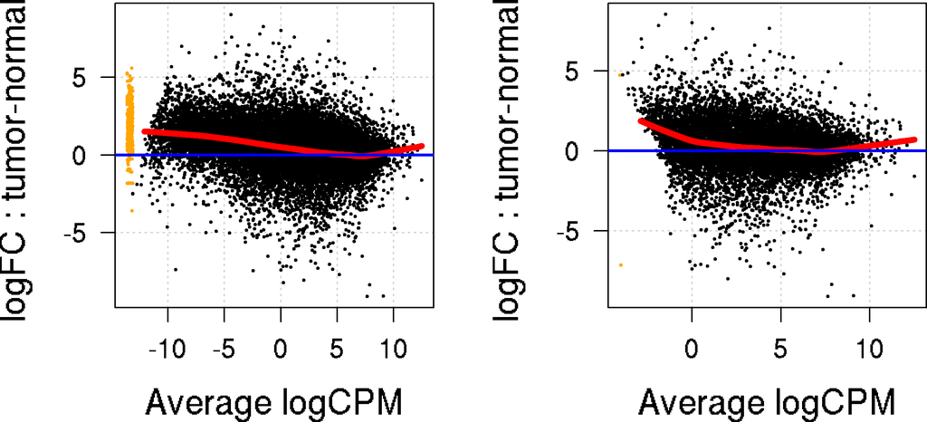

Figure 5: Normalized filtered expression data (right) and unnormalized unfiltered expression data (left)

```r
#Unnormalized first filtered data set
par(mfrow = c(1, 2))
dge.filt$samples$group <- se.filt$type
plotSmear(dge.filt, lowess = TRUE, las = 1, cex.lab = 1.5, cex.axis = 1.2)
abline(h = 0, col = "blue", lwd = 2)
#Normalized second filtered dataset
dge.filt2 <- calcNormFactors(dge.filt2)
dge.filt2$samples$group <- se.filt2$type
plotSmear(dge.filt2, lowess = TRUE, las = 1, cex.lab = 1.5, cex.axis = 1.2)
abline(h = 0, col = "blue", lwd = 2)
```

```r
table(dge.filt2$samples$group)
```

```
##
## normal  tumor
##     72    524
```

After the normalization on the filtered expression data we correct two previous artifacts:

1. A majority of genes seem to be upregulated under a condition where we do not expect it.
2. Large fold changes tend to occur at low expression levels (orange color in the left plot), because ratios between low numbers may easy lead to large fold-changes.

## 2.7 Batch Identification (third filtering)

Using the TCGA barcode from the samples we can asses whether the plate idenfitier, tissue source site, portion analyte, sample vial and center can work as surrogates for batch effect indicators.

```r
tss <- substr(colnames(se.filt2), 6, 7)
center <- substr(colnames(se.filt2), 27, 28)
plate <- substr(colnames(se.filt2), 22, 25)
portionanalyte <- substr(colnames(se.filt2), 18, 20)
samplevial <- substr(colnames(se.filt2), 14, 16)

table(data.frame(TYPE=se.filt2$type, TSS=tss))
```

```
##         TSS
## TYPE      3Z  6D  A3  AK  AS  B0  B2  B4  B8  BP  CJ  CW  CZ  DV  EU  G6  GK
##   normal   0   0   2   0   0  16   2   0   5   0  10  10  27   0   0   0   0
##   tumor    1   1  50  22   2 103  15   9  31 140  69  15  40  13   4   3   1
##         TSS
## TYPE      MM  MW  T7
##   normal   0   0   0
##   tumor    3   1   1
```

```r
table(data.frame(TYPE=se.filt2$type, CENTER=center))
```

```
##         CENTER
## TYPE      07
##   normal  72
##   tumor  524
```

```r
table(data.frame(TYPE=se.filt2$type, PLATE=plate))
```

```
##         PLATE
## TYPE     0864 1188 1277 1289 1305 1325 1334 1420 1426 1503 1541 1672 1758
##   normal    0    0    0    0    0    0    0    0    0   22   31   15    3
##   tumor    16    6   39   49   46   46   47   47   45   44   59   41    0
##         PLATE
## TYPE     1766 1858 A266 A277 A32Z A33J A37O A39I
##   normal    0    1    0    0    0    0    0    0
##   tumor     2    0   10    3    1   10   12    1
```

```r
table(data.frame(TYPE=se.filt2$type, SAMPLEVIAL=samplevial))
```

```
##         SAMPLEVIAL
## TYPE     01A 01B 05A 11A
##   normal   0   0   0  72
##   tumor  520   3   1   0
```

```r
table(data.frame(TYPE=se.filt2$type, PORTIONANALYTE=portionanalyte))
```

```
##         PORTIONANALYTE
## TYPE     01R 02R 03R 11R 12R 13R 21R
##   normal  69   3   0   0   0   0   0
##   tumor  308 115   1  94   3   1   2
```

A simple glance is enough to see that the sample distribution is not correctly performed. It is somehow expected as the number of tumor samples is higher than the normal ones. However, normal samples should have been distributed better. We then filter the samples that are best distributed among all these 4 variables (not in center, as all samples comes from the same).

```r
## Filtering by batch effect indicators
tss_list <- c("A3","B0","B2","B8","CW","CZ")
plate_list <- c(1503,1541,1672)
samplevial_list <- c("01A","11A")
portion <- "01R"
the_mask <- (substr(colnames(dge.filt),6,7) %in% tss_list & substr(colnames(dge.filt),22,25) %in% plate_list & substr(colnames(dge.filt),18,20) == portion & substr(colnames(dge.filt),14,16) %in% samplevial_list)
se.filt3 <- se.filt2[,the_mask]
dge.filt3 <- dge.filt2[,the_mask]
dim(se.filt3)
```

```
## [1] 14777   115
```

```r
## Checking that now the sample distribution is correct
tss2 <- substr(colnames(se.filt3), 6, 7)
plate2 <- substr(colnames(se.filt3), 22, 25)
portionanalyte2 <- substr(colnames(se.filt3), 18, 20)
samplevial2 <- substr(colnames(se.filt3), 14, 16)

table(data.frame(TYPE=se.filt3$type, TSS=tss2))
```

```
##         TSS
## TYPE     A3 B0 B2 B8 CW CZ
##   normal  2 15  2  2  9 26
##   tumor   2 15  4  7  8 23
```

```r
table(data.frame(TYPE=se.filt3$type, PLATE=plate2))
```

```
##         PLATE
## TYPE     1503 1541 1672
##   normal   20   23   13
##   tumor    39   18    2
```

```r
table(data.frame(TYPE=se.filt3$type, SAMPLEVIAL=samplevial2))
```

```
##         SAMPLEVIAL
## TYPE     01A 11A
##   normal   0  56
##   tumor   59   0
```

```r
table(data.frame(TYPE=se.filt3$type, PORTIONANALYTE=portionanalyte2))
```

```
##         PORTIONANALYTE
## TYPE     01R
##   normal  56
##   tumor   59
```

After the third filtering, the sample distribution is much better, thus we have corrected the batch effect, but the number of samples decreases from 596 to 115 (56 normal, 59 tumor).

## 2.8 Batch effect: hierarchical clustering (fourth filtering)

We perform a hierarchical clustering of the samples indicating the batch to which each of them belongs to, to check if there is still some batch that might be confounding the outcome of interest.

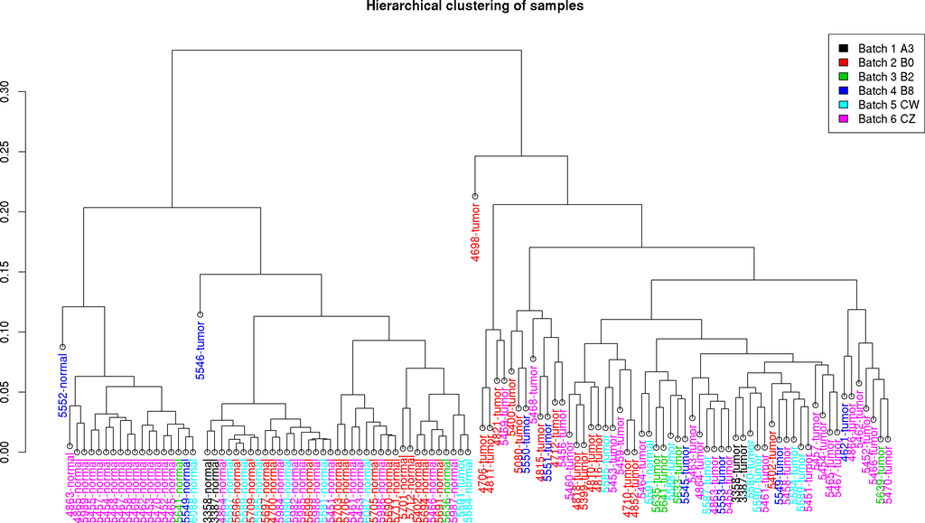

Figure 6: Hierarchical clustering of the samples, colored by Tissue Source Site (TSS)

```r
logCPM <- cpm(dge.filt3, log=TRUE, prior.count=3)
d <- as.dist(1-cor(logCPM, method="spearman"))
sampleClustering <- hclust(d)

## Batch: Tissue Source Site (TSS)
batch <- as.integer(factor(tss2))
sampleDendrogram <- as.dendrogram(sampleClustering, hang=0.1)
names(batch) <- colnames(se.filt3)
outcome <- paste(substr(colnames(se.filt3), 9, 12), as.character(se.filt3$type), sep="-")
names(outcome) <- colnames(se.filt3)
sampleDendrogram <- dendrapply(sampleDendrogram,
                               function(x, batch, labels) {
                                 if (is.leaf(x)) {
                                   attr(x, "nodePar") <- list(lab.col=as.vector(batch[attr(x, "label")]))
                                   attr(x, "label") <- as.vector(labels[attr(x, "label")])
                                 }
                                 x
                               }, batch, outcome)
plot(sampleDendrogram, main="Hierarchical clustering of samples")
legend("topright", paste("Batch", sort(unique(batch)), levels(factor(tss2))), fill=sort(unique(batch)))
```

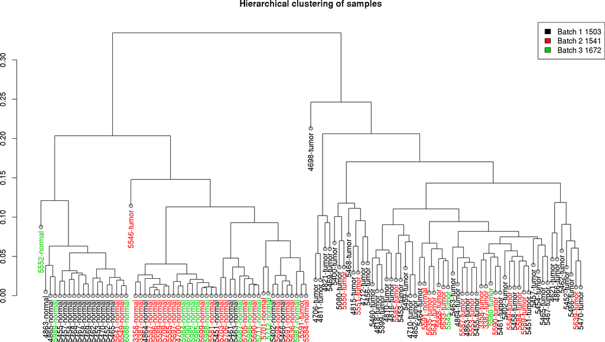

Figure 7: Hierarchical clustering of the samples, colored by Plate

```r
## Batch: Plate
batch <- as.integer(factor(plate2))
sampleDendrogram <- as.dendrogram(sampleClustering, hang=0.1)
names(batch) <- colnames(se.filt3)
outcome <- paste(substr(colnames(se.filt3), 9, 12), as.character(se.filt3$type), sep="-")
names(outcome) <- colnames(se.filt3)
sampleDendrogram <- dendrapply(sampleDendrogram,
                               function(x, batch, labels) {
                                 if (is.leaf(x)) {
                                   attr(x, "nodePar") <- list(lab.col=as.vector(batch[attr(x, "label")]))
                                   attr(x, "label") <- as.vector(labels[attr(x, "label")])
                                 }
                                 x
                               }, batch, outcome)
plot(sampleDendrogram, main="Hierarchical clustering of samples")
legend("topright", paste("Batch", sort(unique(batch)), levels(factor(plate2))), fill=sort(unique(batch)))
```

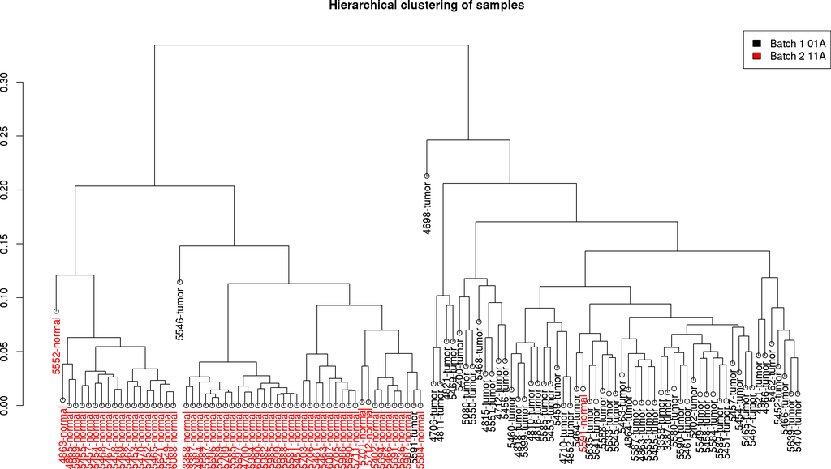

Figure 8: Hierarchical clustering of the samples, colored by Sample Vial

```r
## Batch: Sample Vial
batch <- as.integer(factor(samplevial2))
sampleDendrogram <- as.dendrogram(sampleClustering, hang=0.1)
names(batch) <- colnames(se.filt3)
outcome <- paste(substr(colnames(se.filt3), 9, 12), as.character(se.filt3$type), sep="-")
names(outcome) <- colnames(se.filt3)
sampleDendrogram <- dendrapply(sampleDendrogram,
                               function(x, batch, labels) {
                                 if (is.leaf(x)) {
                                   attr(x, "nodePar") <- list(lab.col=as.vector(batch[attr(x, "label")]))
                                   attr(x, "label") <- as.vector(labels[attr(x, "label")])
                                 }
                                 x
                               }, batch, outcome)
plot(sampleDendrogram, main="Hierarchical clustering of samples")
legend("topright", paste("Batch", sort(unique(batch)), levels(factor(samplevial2))), fill=sort(unique(batch)))
```

```r
se.filt4 <- se.filt3[,grep("5546|5591|4698", colnames(se.filt3), invert=TRUE)]
dge.filt4 <- dge.filt3[,grep("5546|5591|4698", colnames(dge.filt3), invert=TRUE)]
## We keep the discarded sumples just in case want to analyze them later on
se.dis <- se.filt3[,grep("5546|5591|4698", colnames(se.filt3))]
tss3 <- substr(colnames(se.filt4), 6, 7)
plate3 <- substr(colnames(se.filt4), 22, 25)
portionanalyte3 <- substr(colnames(se.filt4), 18, 20)
samplevial3 <- substr(colnames(se.filt4), 14, 16)
dim(dge.filt4)
```

```
## [1] 14777   111
```

## 2.9 Batch effect: Multidimensional scaling

Now we make use of multidimensional scaling plots to check, first if there is a batch effect by gender?, and second other potential variables that might be a new outcome of interest in tumor samples: cancer stage, tumor grade, cancer laterality, and vital status

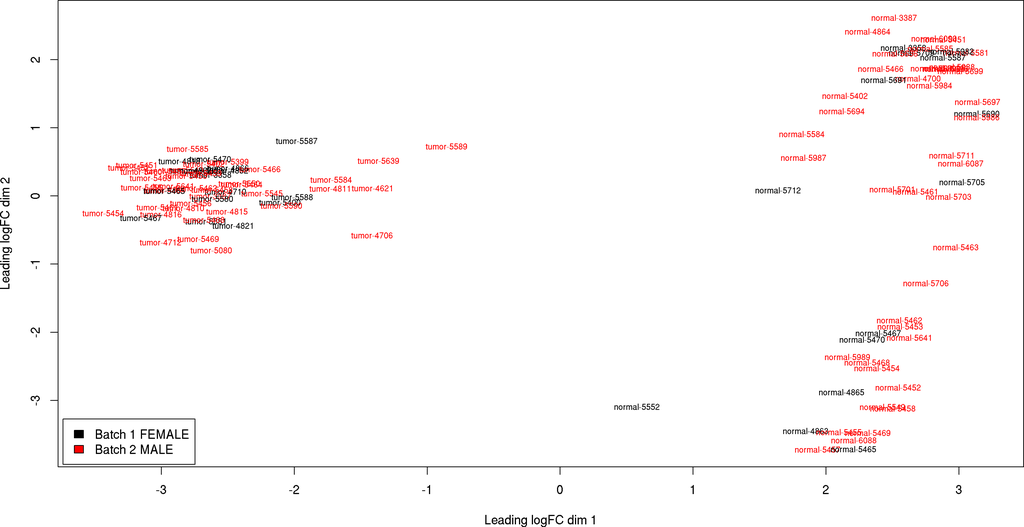

Figure 9: Multidimensional Scaling Plot for the batch effect of Gender

```r
tumor_se <- se.filt4[,se.filt4$type == "tumor"]
tumor_dge <- dge.filt4[,se.filt4$type == "tumor"]

## Gender
se_gender <- se.filt4[,!is.na(se.filt4$gender)]
dge_gender <- dge.filt4[,!is.na(se.filt4$gender)]
batch <- as.integer(factor(se_gender$gender))
outcome <- paste(factor(se_gender$type), substr(colnames(dge_gender), 9, 12), sep="-")
plotMDS(dge_gender, col = batch,labels = outcome, cex = 0.7)
legend("bottomleft", paste("Batch", sort(unique(batch)), levels(factor(se_gender$gender))), fill=sort(unique(batch)), inset=0.005)
```

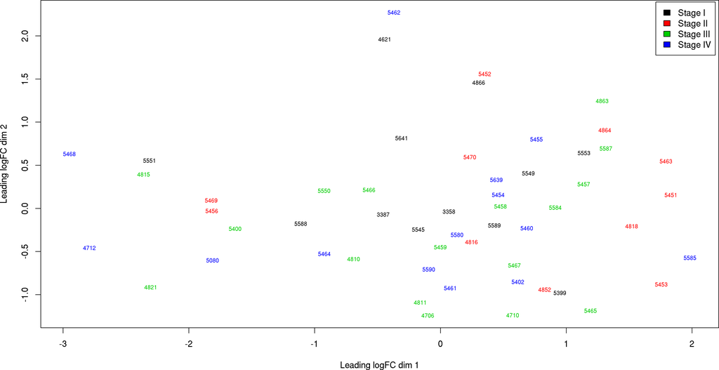

Figure 10: Multidimensional Scaling Plot for the outcome of interest Cancer Stage

```r
## Cancer stage
tumor_stage_se <- tumor_se[,!is.na(tumor_se$ajcc_pathologic_tumor_stage)]
tumor_stage_dge <-tumor_dge[,!is.na(tumor_se$ajcc_pathologic_tumor_stage)]
batch <- as.integer(factor(tumor_stage_se$ajcc_pathologic_tumor_stage))
outcome <- substr(colnames(tumor_stage_dge), 9, 12)
plotMDS(tumor_stage_dge, col = batch,labels = outcome, cex = 0.7)
legend("topright", sort(unique(batch)), levels(factor(tumor_stage_se$ajcc_pathologic_tumor_stage)), fill=sort(unique(batch)), inset=0.005)
```

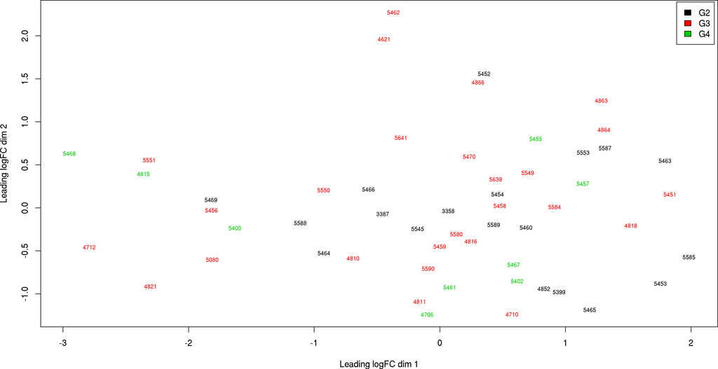

Figure 11: Multidimensional Scaling Plot for for the outcome of interest Tumor Grade

```r
## Tumor grade
tumor_grade_se <- tumor_se[,!is.na(tumor_se$tumor_grade)]
tumor_grade_dge <-tumor_dge[,!is.na(tumor_se$tumor_grade)]
batch <- as.integer(factor(tumor_grade_se$tumor_grade))
outcome <- substr(colnames(tumor_grade_dge), 9, 12)
plotMDS(tumor_grade_dge, col = batch,labels = outcome, cex = 0.7)
legend("topright", sort(unique(batch)), levels(factor(tumor_grade_se$tumor_grade)), fill=sort(unique(batch)), inset=0.005)
```

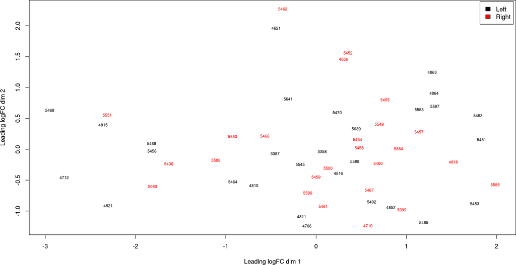

Figure 12: Multidimensional Scaling Plot for for the outcome of interest Cancer Laterality

```r
## Cancer laterality
tumor_late_se <- tumor_se[,!is.na(tumor_se$laterality)]
tumor_late_dge <-tumor_dge[,!is.na(tumor_se$laterality)]
batch <- as.integer(factor(tumor_late_se$laterality))
outcome <- substr(colnames(tumor_late_dge), 9, 12)
plotMDS(tumor_late_dge, col = batch,labels = outcome, cex = 0.7)
legend("topright", sort(unique(batch)), levels(factor(tumor_late_se$laterality)), fill=sort(unique(batch)), inset=0.005)
```

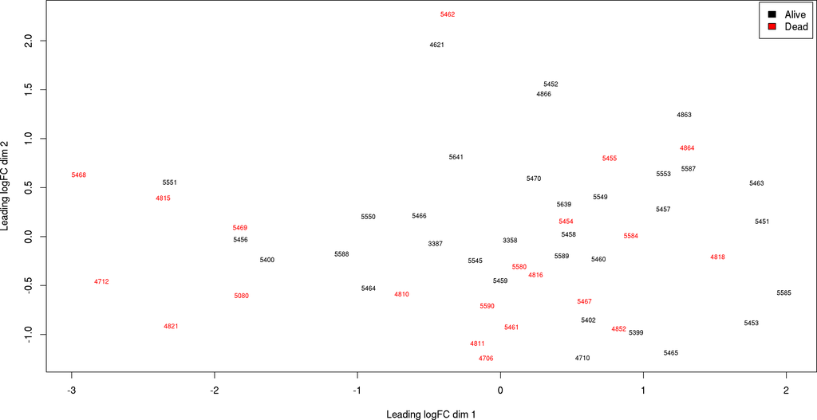

Figure 13: Multidimensional Scaling Plot for for the outcome of interest Vital Status

```r
## Vital status
tumor_status_se <- tumor_se[,!is.na(tumor_se$vital_status)]
tumor_status_dge <-tumor_dge[,!is.na(tumor_se$vital_status)]
batch <- as.integer(factor(tumor_status_se$vital_status))
outcome <- substr(colnames(tumor_status_dge), 9, 12)
plotMDS(tumor_status_dge, col = batch,labels = outcome, cex = 0.7)
legend("topright", sort(unique(batch)), levels(factor(tumor_status_se$vital_status)), fill=sort(unique(batch)), inset=0.005)
```

The first plot (figure 9) shows that there is no correlation between the gender and the logarithm of the fold change for the genes among the samples, which clusters them according to the outcome of interest (tumor or normal), for males and females are uniformly distributed among the two groups, considereing that there are more males than females.The rest of the plots (figures 10, 11, 12, 13) do not show any cluster by the new outcomes of interest in the tumor samples, rejecting the alternative hypothesis of significant differences among the groups in the four variables (although it should be statistically tested in order to properly confirm it).

# 3 Differential expression

We perform a simple examination of expression changes and their associated p-values using the sva R/bionconductor package.

```r
mod <- model.matrix(~ se.filt4$type, colData(se.filt4))
mod0 <- model.matrix(~ 1, colData(se.filt4))
pv <- f.pvalue(assays(se.filt4)$logCPM, mod, mod0)
sum(p.adjust(pv, method="fdr")< 0.01)
```

```
## [1] 10640
```

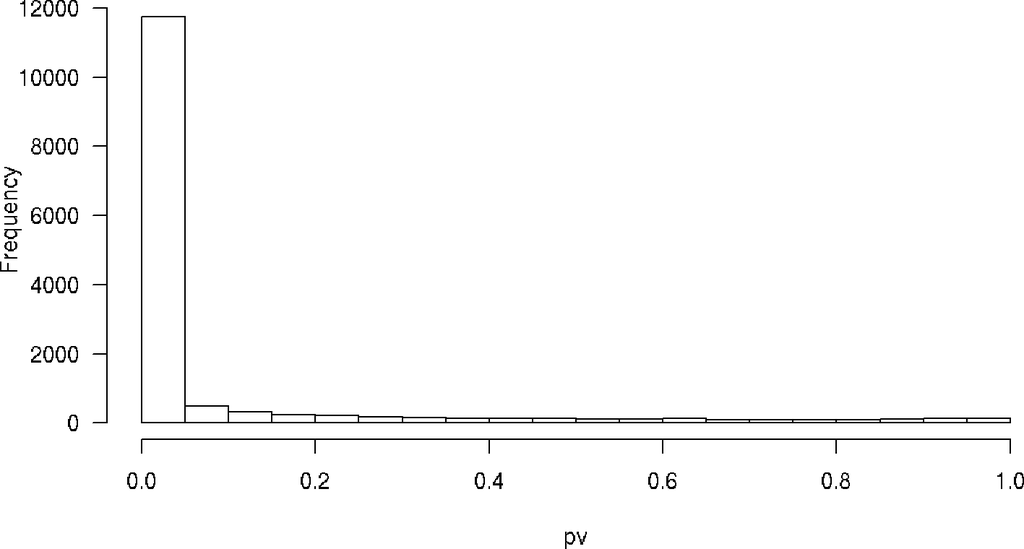

Figure 14: Distribution of raw p-values for an F-test on every gene between tumor and normal samples

```r
hist(pv, main="",las=1)
```

There are 10640 genes changing significantly their expression at FDR < 1%. Figure 14 from above shows the distribution of the resulting p-values.

## 3.1 Estimation of surrogate variables

Surrogate variables are sources of hereogeneity in high-throughput profiling data, such as non-biological variability introduced by batch effects. We use the to estimate the surrogate variables and adjust by these confounding effects. The previous model matrices are needed.

```r
sv <- sva(assays(se.filt4)$logCPM, mod, mod0)
```

```
## Number of significant surrogate variables is:  18
## Iteration (out of 5 ):1  2  3  4  5
```

```r
sv$n
```

```
## [1] 18
```

The SVA algorithm has found 18 surrogate variables. Now, we use them to assess against the extent of differential expression, this time adjusting for these surrogate variables.

```r
modsv <- cbind(mod, sv$sv)
mod0sv <- cbind(mod0, sv$sv)
pvsv <- f.pvalue(assays(se.filt4)$logCPM, modsv, mod0sv)
sum(p.adjust(pvsv,method="fdr")<0.01)
```

```
## [1] 12031
```

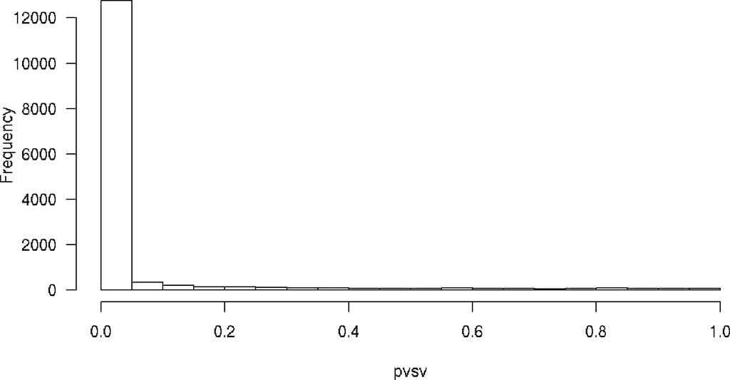

Figure 15: Distribution of raw p-values for an F-test on every gene between tumor and normal samples, after SVA

```r
hist(pvsv, main="",las=1)
```

We have increased the number of changing genes to 12031. Figure 15 from above shows the distribution of the resulting p-values.

# References

TCGA, The Cancer Genome Atlas Research Network. 2013. “Comprehensive Molecular Characterization of Clear Cell Renal Cell Carcinoma.” *Nature* 499. The Author(s): 43–49.